# Bootcamp worksheet

Axel Barlow

04-11-2024

## Unix-like systems and bash

### 1. Logging on to SCW

- Consult guide from Ade Fewings: https://bangoroffice365.sharepoint.com/sites/DigitalServices/SitePages/eResearch---Access-to-the-Hawk-Supercomputer.aspx
- Windows users need to download a SSH client. We will use MobaXterm portable edition: https://download.mobatek.net/2432024101610907/MobaXterm_Portable_v24.3.zip
- Linux and Mac users can just ssh from the terminal
- Note your bangor_username and hawk_username are different
- bangor_username has you normal password
- hawk_username password (suggest no special characters) can be set at: https://scw.bangor.ac.uk/en-gb/

```bash
# Windows
# Unzip and open the downloaded MobaXterm executable
# In MobaXterm, click on the 'Session' icon at the top left.
# Choose 'SSH' as the session type.
# In the 'Remote host' field, enter ssh.bangor.ac.uk
# Login using your Bangor username with MFA
# initiate an SSH connection to the Hawk supercomputer:

ssh hawk_username@hawklogin.cf.ac.uk

# Linux/Mac
# Open a terminal

ssh bangor_username@ssh.bangor.ac.uk
ssh hawk_username@hawklogin.cf.ac.uk
```

### 2. Basic bash commands

Unix-like (linux and Mac) generally use a bash shell (or something like it).

“*Bash is a command processor that typically runs in a text window where the user types commands that cause actions. Bash can also read and execute commands from a file, called a shell script. Like most Unix shells, it supports filename globbing (wildcard matching), piping, here documents, command substitution, variables, and control structures for condition-testing and iteration.*”

See https://en.wikipedia.org/wiki/Bash_(Unix_shell)

```bash
# print working directory
pwd

# make directory
mkdir my_directory

# change directory
cd my_directory

# print working directory
pwd

# print something to screen
echo "hello"

# redirect output to file
echo "hello" > hello.txt

# list contents of directory
ls

# help menu
ls --help

# view contents of file
cat
less
head

# print something else to file
echo "hello2" > hello.txt
echo "hello" > hello.txt
echo "hello2" >> hello.txt

# count lines and characters
wc -l
wc -c

# search for content in files
grep --help
grep "2" hello.txt

# pipes
grep "2" hello.txt | wc -l

# deleting (CAREFUL!!!)
rm hello.txt

# let's make some more files
yes hello | head -n 100 > my_file1.txt
yes goodbye | head -n 100 > my_file2.txt

# wildcards
cat my_file* > my_combined_file.txt

# a note on file extensions
mv my_combined_file2.txt my_combined_file2.mp3
mv my_combined_file2.txt my_combined_file2

# deleting with wildcards (VERY CAREFUL!!!)
rm my*

# Download file from internet
wget https://dnazoo.s3.wasabisys.com/Alligator_mississippiensis/ASM28112v4_HiC.fasta.gz

# Note file is compressed with gzip compression
# view contents without unzipping
zcat ASM28112v4_HiC.fasta.gz | less

# uncompress
gunzip ASM28112v4_HiC.fasta.gz
# note you can compress with the command gzip

# log off
exit
```

### 3. Your turn :)

- Count number of scaffold names in the Alligator genome
- Print scaffold names to a file
- Print only scaffold names 10 to 20 to a file
- Count the number of bases in the first line of DNA sequence (i.e. line 2)
- Work out the genome size (don’t worry about newline characters in your base counts for now)
- If you are finished early, you can find a genome of your choice to play around with
- Or… look at setting up a jump host and data transfer to your local PC: https://bangoroffice365.sharepoint.com/sites/DigitalServices/SitePages/eResearch---Access-to-the-Hawk-Supercomputer.aspx

### 4. Basic bash commands 2

```bash
# We assume you are in /home/hawk_username/my_directory. Check!
pwd

# let's make a file of random numbers
# we can use the bash variable $RANDOM (more on variables later)
# write 10 random numbers to a file
echo $RANDOM >> my_randoms.txt

# sort the numbers
sort my_randoms.txt

# check for duplicates
sort my_randoms.txt | uniq -c

# stream editing: sed
# see https://www.gnu.org/software/sed/manual/sed.html
# sed 's/search_string/replace_string/g' inputfile
# s = substitute
# g = global
sed --help
sed 's/1/Axel/g' my_randoms.txt

# something more complex
# . all characters
# \0 [replace with] the same character
sed 's/./\0 /g' my_randoms.txt
```

### 5. Your turn

- Using the help menu and Google, work out how to get grep to report the line numbers of each scaffold header in the Alligator genome file
- Extract the sequence of the first scaffold and calculate the base composition (number of A, T, G, C)
- If you are finished early, play around some more. For example can calculate base composition of the entire genome ignoring header lines?

```bash
# extracting the scaffold
head -n 5576894 ASM28112v4_HiC.fasta | tail -n 5576893 > scaffold_1.txt

# Axel's solution using sed. Slow!
# sed 's/./\0\n/g' enters newline after each character
sed 's/./\0\n/g' scaffold_1.txt | sort | uniq -c

# Jeronimo et al's method using greps, faster!
# -o print all matches
# -i case insensitive
grep -o -i a scaffold_1.txt
grep -o -i t scaffold_1.txt
grep -o -i g scaffold_1.txt
grep -o -i c scaffold_1.txt

# Ruby's method using tr, Fastest!
# -c complement, find opposite of match
# -d delete
tr -cd 'Aa' < scaffold_1.txt | wc -c
tr -cd 'Tt' < scaffold_1.txt | wc -c
tr -cd 'Gg' < scaffold_1.txt | wc -c
tr -cd 'Cc' < scaffold_1.txt | wc -c
```

### 6. Bash scripts

- Bash scripts allow sets of commands to be executed in an automated fashion
- Files contain bash scripts are given the extension `.sh` by convention
- fist line is the bash **shebang**, it instructs the system to parse the file using `bash` (as opposed to `python, perl, R`, etc.)
- lines starting `#` are comments
- commands are executed from top to bottom

```bash
#!/bin/bash

# let's make some files
yes hello | head -n 100 > my_file1.txt
yes goodbye | head -n 100 > my_file2.txt

# combine files
cat my_file* > my_combined_file.txt

echo "job finished"
```

#### A note on text editors

- never (ever) use a word processor
- plain text editor (many available)
- includes terminal plain text editors
- be careful windows people :)
- example: `vim`

```bash
# open file
vim my_script.sh

# enter insert mode
i

# do stuff ######################################

# exit insert mode
[ESC]

# write changes to file
:w

# quit
:q
```

#### Executing bash scripts

```bash
sh my_script.sh
```

### 7. Your turn :)

- Generate the `bash` script described above and execute
- try modifying the script, for example to delete the intermediary files my_file1.txt and my_file2.txt
- If you are finished early, think what other functions you could add to your script. For example lines counts reported to the terminal or saved in a file

### 8. Variables

- In `bash`, variables can be used to store data in memory
- Works exactly like objects in `R`
- After they are defined, variables can be recalled using `$`
- anything entered after the script call becomes variables `$1, $2, $3`, etc.
- Or they can be defined in the script `variable=value`

```bash
#!/bin/bash

# script makes lists of 2 words, which can be entered when the script is called
# $count controls the length of the list
# call the script like:
# sh my_script.sh hello goodbye

# declare variables
count=100

# main script

# let's make some files
yes $1 | head -n $count > my_file1.txt
yes $2 | head -n $count > my_file2.txt

# combine files
cat my_file* > my_combined_file.txt

echo "job finished"
```

### 9. Loops

- Loops are quite an advanced feature, but extremely useful
- here we look at a basic while loop with a counter

```bash
#!/bin/bash

x=0

while [ $x -lt 10 ]; do
  echo The counter is $x
  let x=x+1
done
```

### 10. Your turn :)

- Generate the script shown in part 8. variables
- execute your script, and try changing the variables. Is behaviour as expected?
- try modifying your script, for example entering the counts at the command line, or specifying the name of the output file at the command line
- Generate the script shown in part 9. using a loop. Execute
- If you are finished early… Remember making the file of random numbers above, wasn’t this annoying? Try to make this file and carry out the same operation by making a script incorporating a loop

## Supercomputing Wales and slurm

### 1. Filesystem

```bash
# print working directory
pwd

# list contents of working directory
ls

# move up one level in hierarchy
cd ..

# print working directory
pwd

# list contents of working directory
ls

# move to root directory
cd /

# list contents of working directory
ls

# Go home
cd ~
```

### 2. Modules

```bash
# module searching
module avail
module avail R

# module load
module load R/4.2.0

# module unload
module purge
```

### 3. Slurm

```bash
# You are currently using the log in node.
# Do not run resource-intensive jobs on the log in node!

# use slurm to open an active bash shell on a compute node
srun --nodes=1 --ntasks=4 --mem=4G --time=0-00:20 --pty /bin/bash

# the queue
squeue
squeue -u username

# do something resource intensive
module load pigz
pigz -p 4 ASM28112v4_HiC.fasta

# exit
exit

# check efficiency
seff jobid
```

### 4. Slurm scripts

- Running a live terminal is not very convenient
- We need a way of submitting jobs to the queue: `slurm` job script
- It’s just a bash script, with additional options passed to `slurm` using `#SBATCH`

```bash
#!/bin/bash --login
###
#job name
#SBATCH --job-name=example
#job stdout file
#SBATCH --output=/path/to/dir/example%J
#job stderr file
#SBATCH --error=/path/to/dir/example_err%J
#maximum job time in D-HH:MM
#SBATCH --time=0-00:01
#number of nodes
#SBATCH --nodes=1
#number of parallel processes (tasks)
#SBATCH --ntasks=1
#memory in Gb
#SBATCH --mem=1G

echo hello > hello.txt
```

```bash
# submit to queue
sbatch job_script.sh
```

#### For people who have multiple accounts

- If you have multiple accounts on SCWales, the command above will throw an error
- You can specify the acount at the command line, or include in the slurm script

```bash
#command line
sbatch account=scw1234 job_script.sh

# or include the following SBATCH in the script

#assign account
#SBATCH account=scw1234
```

### 5. Your turn :)

- make 2 new directories in your `home`: `my_slurm_scripts` and `output_logs`
- make a copy of the `slurm` script in `./my_slurm_scripts`
- Direct stdout and error messages to `./output_logs`
- Specify 1 node, 4 cpus, 8Gb RAM, 1 hour
- Submit job to queue

**Next**

- You are going to implement the method you developed to print scaffold names to a file from the alligator genome in part 3. as a `slurm` script.
- Make a `slurm` script in `./my_slurm_scripts`
- You should work on the **compressed** file located in your `home` directory
- use pigz to decompress the genome file and then re-compress after doing the computation
- Direct stdout and error messages to `./output_logs`
- Specify 1 node, 8 cpus, 16Gb RAM, 1 hour
- Submit job to queue

## Example alligator script

```bash
#!/bin/bash --login
###
#job name
#SBATCH --job-name=gator
#job stdout file
#SBATCH --output=../output_logs/std_%J
#job stderr file
#SBATCH --error=../output_logs/err_%J
#maximum job time in D-HH:MM
#SBATCH --time=0-01:00
#number of nodes
#SBATCH --nodes=1
#number of parallel processes (tasks)
#SBATCH --ntasks=8
#memory in Gb
#SBATCH --mem=16G

# load modules
module purge
module load pigz

# decompress
unpigz -p 8 ../ASM28112v4_HiC.fasta.gz

# collect scaffold names
grep ">" ../ASM28112v4_HiC.fasta > ../scaffold_names.txt

# recompress
pigz -p 8 ../ASM28112v4_HiC.fasta

echo "job complete"
```

## New for 2024: paths of glory game :)

```bash
# start in your home
cd

# Copy the contents of this file:
/scratch/scw2141/oooooo/its/such/a/long/filepatch/paths_of_glory.txt

# To a file named with your name, here:
/scratch/scw2141/and/did/he/use/caPITAls/what/a/masochist/
```

## Illumina data processing

### 1. Fastq file format

```bash
# enter BEARCAVE
cd /scratch/scw2141/BEARCAVE2/

# view directories
ll

# raw data
cd rawdata

# look at a fastq file
zcat ./adder01/a01+adder01_R1.fastq.gz | less

# look at metadata
cat ./metadata.txt

# look at reference genome
less /scratch/scw2141/BEARCAVE2/refgenomes/berus_chr7/berus_chr7.fa
```

### 2. Your turn :)

- locate sequence data for your adder
- What are the file sizes of R1 and R2 files?
- How many R1 and R2 sequences are there?
- What is the read length?
- What can you surmise about the arrangement of R1 and R2 data, and how do you explain the file sizes?

### 3. BEARCAVE script: trim and merge

```bash
less BEARCAVE2/scripts/trim_merge_DS_PE_standard2.sh
```

```bash
#!/bin/bash

# Hacked by Axel, April 2023
# For use on Hawk which has shiny modules, using new cutadapt and pigz to allow multithreading
# you will need to load the following modules in your slurm script:
# module load cutadapt/4.3 FLASH/1.2.11 pigz/2.4

# November 2018
# script for trimming adapter sequences from DS library PE data, removing short reads, amd merging overlapping PE reads.
# this script is for data sequenced using the standard Illumina R1 sequencing primer

# this script should be run from /BEARCAVE/scripts

# example command line: sh ./trim_merge_DS_PE_standard2.sh $1 $2 $3
# $1 = SAMPLE*
# $2 = PREFIX*
# $3 = SEQ_RUN*

# * these can be found in /BEARCAVE/rawdata/metadata.txt
```

### 4. Your turn :)

- make a `slurm` job script in your chosen location within home directory. It should do the following steps.
- Note you will need to add the following SBATCH to your script, to ensure the command is executed in the scripts directory:

```bash
#set working directory
#SBATCH --chdir=/scratch/scw2141/BEARCAVE2/scripts/
```

- load appropriate modules
- run the trim_merge_DS_PE_standard2.sh script on your adder sample
- use 4Gb RAM, 10 CPUs, and run for 1 hour
- direct stdout and errors to your chosen location in your home directory
- submit to queue

### 5. BEARCAVE script: mapping

```bash
less BEARCAVE2/scripts/map_modern_PE_mem2.sh
```

```bash
#!/bin/bash

# Hacked by Axel, April 2023
# For use on Hawk which has shiny modules, using new bwa and samtools
# this uses the improved duplicate removal method (not rmdup)
# you will need to load the following modules in your slurm script:
# module load bwa/0.7.17 samtools/1.17 pigz/2.4

# November 2018
# script for mappping modern DNA reads to a reference genome
# note this includes mapping of both merged and unmerged paired-end reads

# this script should be run from /BEARVACE/scripts

# example command line: sh ./map_modern_PE_mem2.sh $1 $2 $3 $4
# $1 = prefix or prefixes (if you are mapping combined data file, you should enter its while set of prefixes as one argument, like this: pr1_pr2_pr3
# $2 = reference - folder name in /refgenomes/
# $3 = 3 character taxon identifier, used for filenaming - e.g. arc, spe, kud, mar.
# $4 = sample name
```

### 6. Your turn :)

- check the outcome of the trimming and merging
- move your processed files into `/scratch/scw2141/BEARCAVE2/trimdata/`
- move your log files into `/scratch/scw2141/BEARCAVE2/trimdata/trimlogs`
- delete the *processing directory
- make a slurm job script similar to the one in part 4. in your chosen location within home directory. This script should execute the map_modern_PE_mem2.sh script
- Use 10Gb RAM, 10 CPUs, and run for 4 hours
- Check outcome

## PCA, NJ tree and heterozygosity

We will carry out population gneomics analyses using `angsd`. This requires a list of bamfiles to analyse. For example:

```bash
# angsd requires a list on bam files in a text file
ls -1 /scratch/scw2141/BEARCAVE2/mappedberus_chr7/*bam > bamlist
```

### 1. Distance matrix

```bash
# load angsd module
module purge
module load angsd/0.935

# set ref genome as a variable
ref='/scratch/scw2141/BEARCAVE2/refgenomes/berus_chr7/berus_chr7.fa'

# angsd command
#-doIBS,-doCounts = Identity by state, currently set as single read sampling
#-doCov  = calculate covariance matrix
#-makeMatrix = calculate distance matrix
#-doMajorMinor, -GL = identify major/minor allele using genotype likelihoods
#-minFreq = min allele frequency for site
#-minInd = min individuals with data
#-minQ,-minMapQ = min base and map quality
#-b = specify bamlist
#-ref = reference genome
#-out = name outputs
#-nThreads = number threads

# this calculates the distance matrix, include the outgroup
angsd -doIBS 1 -makeMatrix 1 -doCounts 1 -doMajorMinor 1 -GL 1 -minFreq 0.05 -minInd 28 -minQ 30 -minMapQ 30 -b bamlist_outgroup -ref $ref -out bamlist_outgroup -nThreads 10
```

### 2. Covariance matrix

```bash
# load modules and declare variables as above
# this calculates the covariance matrix, exclude the outgroup
angsd -doIBS 1 -doCov 1 -doCounts 1 -doMajorMinor 1 -GL 1 -minFreq 0.05 -minInd 27 -minQ 30 -minMapQ 30 -b bamlist_ingroup -ref $ref -out bamlist_ingroup -nThreads 10
```

### 3. Heterozygosity

```bash
# set files as variables
input='/scratch/scw2141/BEARCAVE2/mappedberus_chr7/xxx+adderxx_ber_berus_chr7_.xxxxx.bam'
output='adderxx_het'
ref='/scratch/scw2141/BEARCAVE2/refgenomes/berus_chr7/berus_chr7.fa'

# depth variables
max=20
min=3

# estimate genotype likelihoods
# -i = input file
# -doSaf = per-site allele frequencies
# -GL = genotype likelihood model
# -P = number threads
# -anc = outgroup, to identify ancestral allele
#-minQ,-minMapQ = min base and map quality
# -setMinDepthInd, -setMaxDepthInd = max and min depth filters
angsd -i $input -doSaf 1 -GL 1 -P 10 -anc $ref -out $output -minMapQ 30 -minQ 30 -setMinDepthInd $min -setMaxDepthInd $max -doCounts 1

# calculate sfs
# -nSites = sliding window size
# -P = no threads
realSFS $output.saf.idx -nSites 100000 -P 10 > $output.window.sfs
```

### 3. Your turn :)

- Make a slurm job script in you home directory to run the analyses above
- make a bamlist in the same directory
- direct stdout and errors to your chosen location in your home directory
- adjust variables to appropriate paths and filenames
- Use 32Gb RAM, 10 CPUs, and run for 0.5 hours
- Check results
- Look at your *.ibs.gz file and count the lines

## Intro to basic `R` commands

```r
# R is just a big calculator
1+1

# make an object
my_sum <- 1+1

# vectors
my_vec <- c(1,2,3,4)

# functions
length(my_vec)

# plotting
my_vec2 <- c(1,2,3,4) # geenrate data
plot(my_vec, my_vec2)
plot(c(1,2,3,4), c(4,3,2,1))

# sample from a normal distribution
rnorm(500, 10, 1)

# histogram
hist(rnorm(500, 10, 1))

# read in data as a dataframe
my_liz <- read.table("lizard_data.txt", header=TRUE)

# isolate svl data
my_liz$svl
```

### Your turn

- Draw a histogram of lizard body width
- Draw a scatterplot of svl vs width
- Calculate means and standard deviations for each variable
- If you have finished early, try out ways to make your plots more attractive

## Population genetics

### 1. PCA

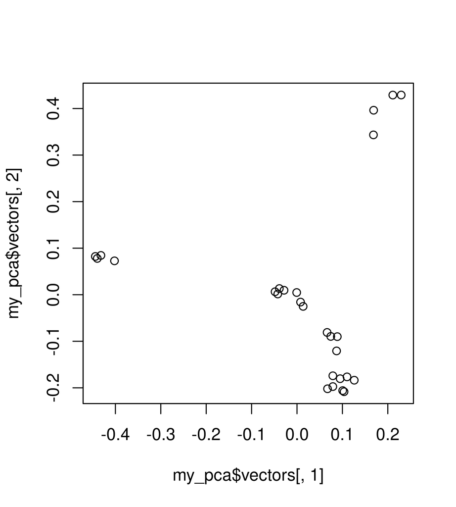

```r
# read in covariance matrix
my_cov <- as.matrix(read.table("assets/data/bamlist_ingroup.covMat"))

# do PCA
my_pca <- eigen(my_cov)

# plot
plot(my_pca$vectors[,1], my_pca$vectors[,2])
```

### 2. NJ tree

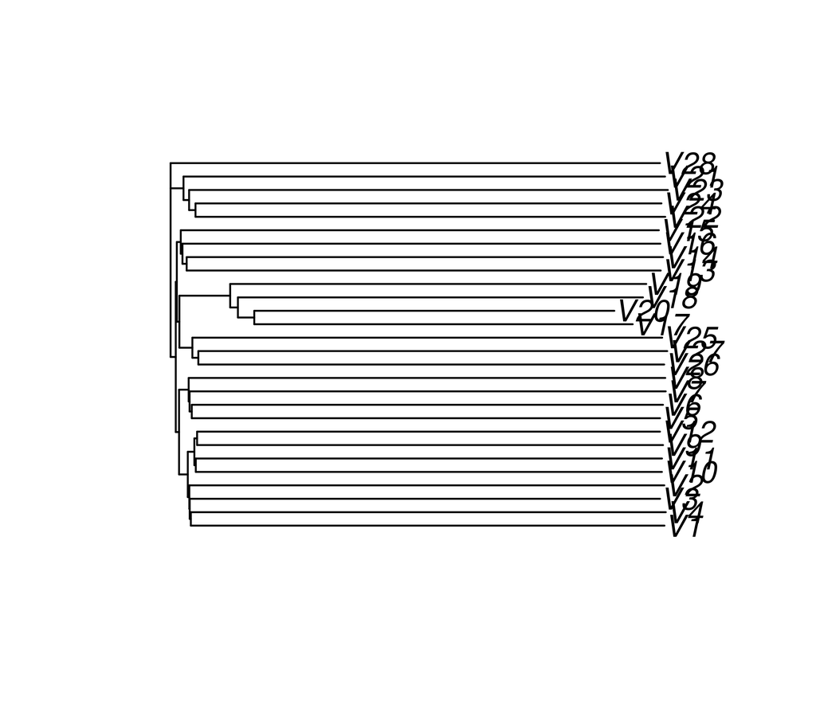

```r
# we use the ape library
library(ape)

# read in matrix
my_mat <- as.matrix(read.table("./assets/data/bamlist_outgroup.ibsMat"))

# compute tree
my_tree <- nj(my_mat)

# plot
my_root <- root(my_tree, outgroup=28)
plot(my_root)
```

### 3. Heterozygosity

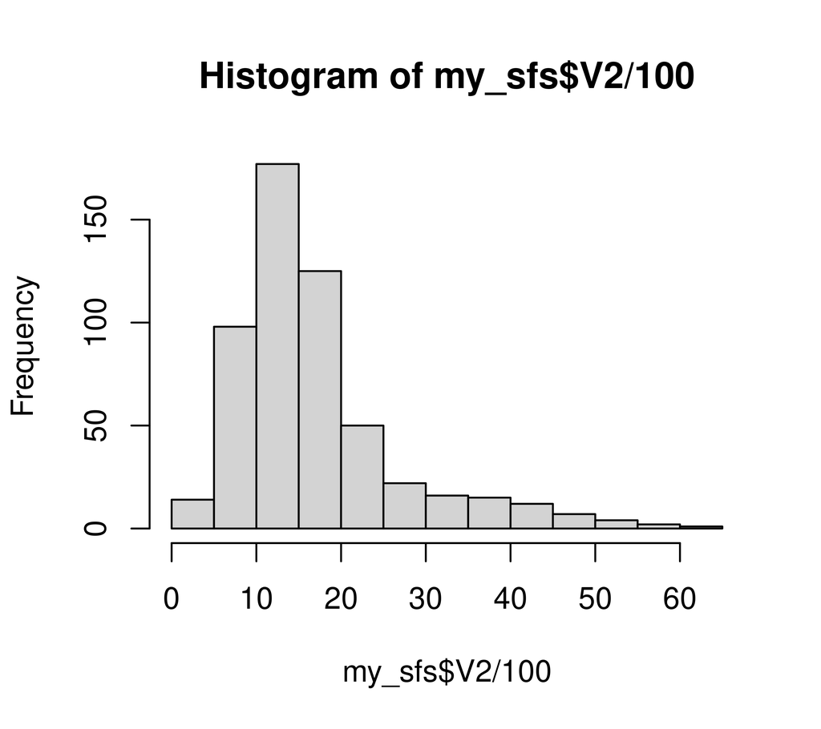

```r
my_sfs <- read.table("./assets/data/adder01_het.window.sfs")
hist(my_sfs$V2/100)
```

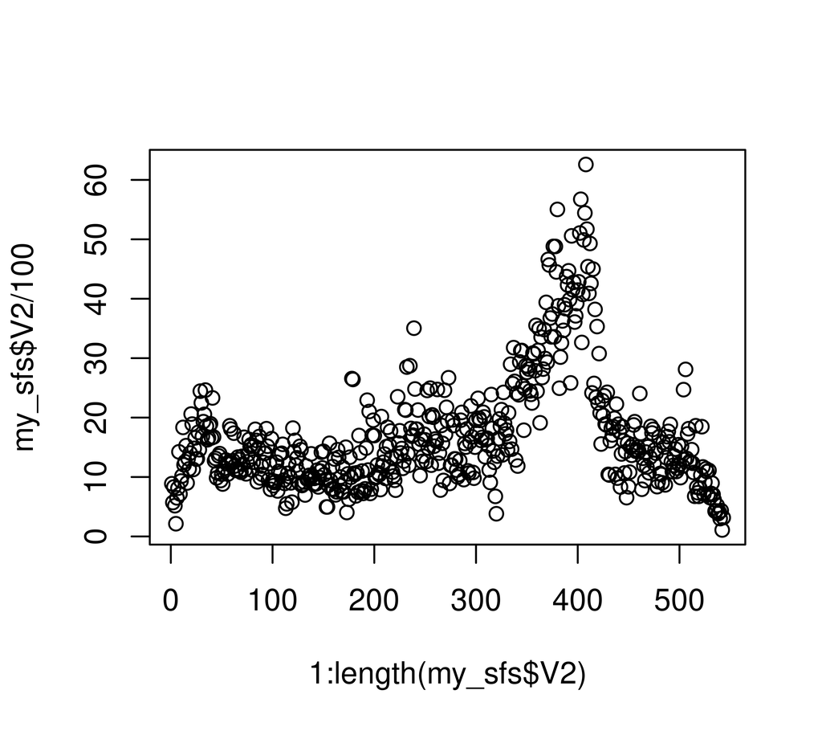

```r
plot(1:length(my_sfs$V2), my_sfs$V2/100)
```

### Your turn

Each plot is in its most basic form. Spend some time trying to improve each one to your liking